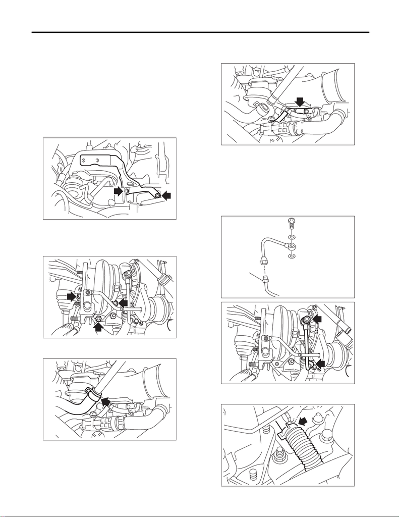

IN(STI)-16

Turbocharger

INTAKE (INDUCTION)

7. Turbocharger

A: REMOVAL

1) Disconnect the ground cable from battery.

2) Drain approximately 3.0 L (3.2 US qt, 2.6 Imp qt)

of coolant. <Ref. to CO(STI)-13, DRAINING OF

ENGINE COOLANT, REPLACEMENT, Engine

Coolant.>

4) Remove the intercooler. <Ref. to IN(STI)-13,

REMOVAL, Intercooler.>

5) Remove the intercooler stay RH No. 2.

6) Remove the center exhaust pipe. <Ref. to

EX(STI)-7, REMOVAL, Center Exhaust Pipe.>

7) Lower the vehicle.

8) Remove the joint pipe from the turbocharger.

9) Disconnect the engine coolant hose from the up-

per side of the water pipe.

10) Disconnect the air control hose (A), and loosen

the clamp holding the intake duct to the turbocharg-

er.

11) Remove the oil inlet pipe from the turbocharg-

er.

CAUTION:

In order to prevent damaging the oil pipe on the

cylinder head side, fix the section (a) shown in

the figure when loosing the oil inlet pipe flare

nut, and avoid the part from rotating together

while loosening the nut.

12) Disconnect the engine coolant hose from the

lower side of the water pipe.

EX-00007

IN-02390

IN-02594

IN-02930

(A)

(a)

IN-02955

IN-02633

IN-02931

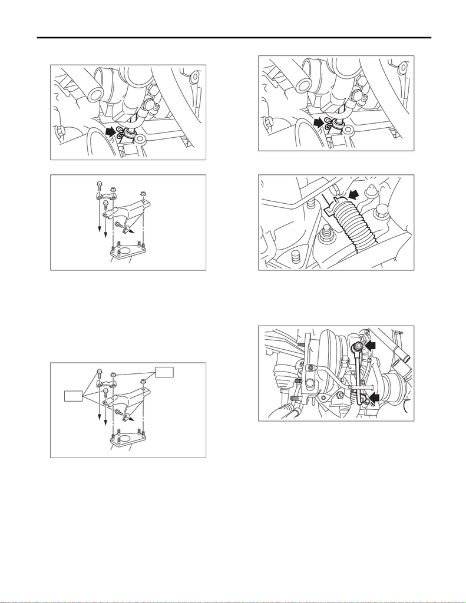

IN(STI)-17

Turbocharger

INTAKE (INDUCTION)

13) Disconnect the oil outlet hose from the oil outlet

pipe, and remove the turbocharger.

14) Remove the turbocharger stay.

B: INSTALLATION

1) Install the turbocharger stay.

Tightening torque:

T1: 33 N·m (3.4 kgf-m, 24.3 ft-lb)

T2: 42.5 N·m (4.3 kgf-m, 31.3 ft-lb)

2) Connect the oil outlet hose to the oil outlet pipe.

3) Connect the engine coolant hose to the lower

side of the water pipe.

4) Temporarily tighten the union bolts and flare

nuts which secure the oil inlet pipe to the turbo-

charger.

NOTE:

Use a new gasket.

(A) To cylinder head RH

(B) To cylinder block RH

(A) To cylinder head RH

(B) To cylinder block RH

IN-02310

IN-02859

(A)

(A)

(B)

T1

IN-02860

(A)

(A)

(B)

T2

IN-02310

IN-02931

IN-02633

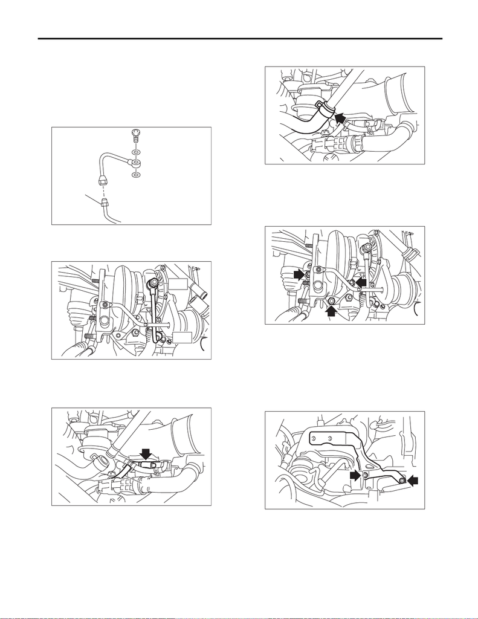

IN(STI)-18

Turbocharger

INTAKE (INDUCTION)

5) Tighten the union bolts and flare nuts which se-

cure the oil inlet pipe to the turbocharger.

CAUTION:

In order to prevent damaging the oil pipe on the

cylinder head side, fix the section (a) shown in

the figure when tightening the oil inlet pipe flare

nut, and avoid the part from rotating together

while tightening the nut.

Tightening torque:

T1: 16 N·m (1.6 kgf-m, 11.8 ft-lb)

T2: 20 N·m (2.0 kgf-m, 14.8 ft-lb)

6) Connect the air control hose (A), and install the

intake duct to the turbocharger.

Tightening torque:

3 N·m (0.3 kgf-m, 2.2 ft-lb)

7) Connect the engine coolant hoses to the upper

side of the water pipe.

8) Install the joint pipe to turbocharger.

NOTE:

Use a new gasket.

Tightening torque:

42.5 N·m (4.3 kgf-m, 31.3 ft-lb)

9) Lift up the vehicle.

10) Install the center exhaust pipe. <Ref. to

EX(STI)-8, INSTALLATION, Center Exhaust

Pipe.>

11) Lower the vehicle.

12) Install the intercooler stay RH No. 2.

Tightening torque:

16 N·m (1.6 kgf-m, 11.8 ft-lb)

13) Install the intercooler. <Ref. to IN(STI)-14, IN-

STALLATION, Intercooler.>

14) Connect the battery ground terminal.

15) Fill engine coolant. <Ref. to CO(STI)-13, FILL-

ING OF ENGINE COOLANT, REPLACEMENT,

Engine Coolant.>

(a)

IN-02955

IN-02613

T1

T2

IN-02930

(A)

IN-02594

IN-02390

EX-00007

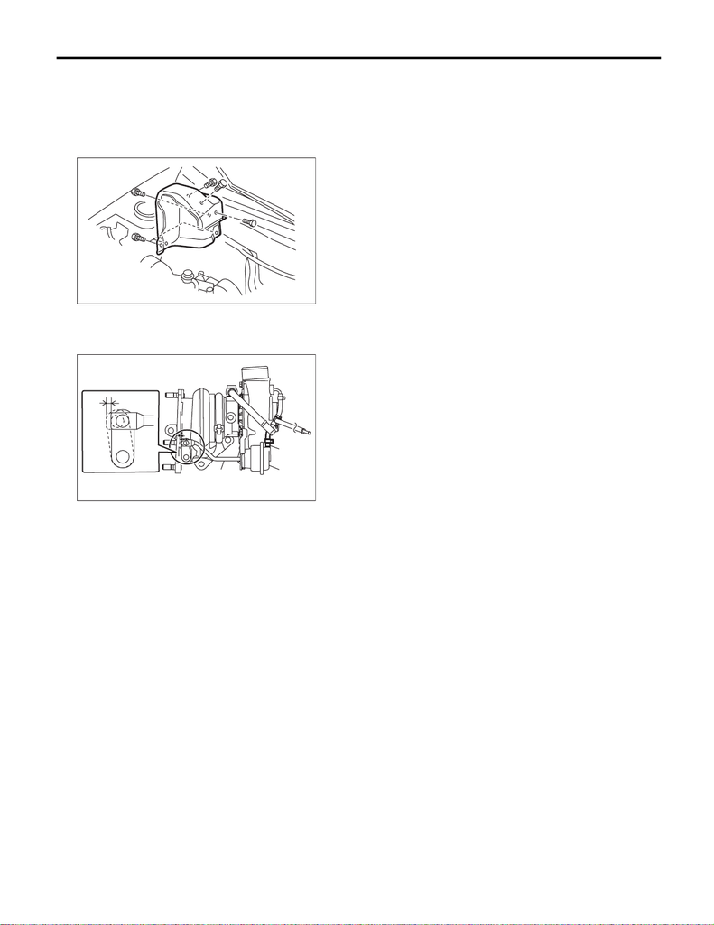

IN(STI)-19

Turbocharger

INTAKE (INDUCTION)

C: INSPECTION

1. WASTE GATE ACTUATOR

1) Remove the intercooler. <Ref. to IN(STI)-13,

REMOVAL, Intercooler.>

2) Remove the turbocharger upper cover.

3) Remove the boost hose (B) from the waste gate

actuator (A) of the turbocharger, and connect the

Mighty Vac to the waste gate actuator (A).

4) Pressurize slowly with the Mighty Vac, and mea-

sure the pressure when the control rod stroke (D)

becomes 2 mm (0.08 in). If it is not within the stan-

dard, replace the turbocharger assembly.

CAUTION:

Do not pressurize over 89.9 kPa (0.92 kg/cm

2

,

13.0 psi) to prevent damaging the waste gate

actuator.

Operating pressure (control rod stroke 2 mm

(0.08 in)):

Standard

74.7 — 80.8 kPa (0.76 — 0.82 kg/cm

2

, 10.8

— 11.7 psi)

5) After inspection, install the related parts in the

reverse order of removal.

Tightening torque:

7.5 N·m (0.8 kgf-m, 5.5 ft-lb)

2. OTHER INSPECTIONS

1) Check that the turbocharger, turbocharger stay

and pipe have no deformation, cracks or other

damages.

2) Check that the hose and intake duct have no

cracks, damage or loose part.

3) Check that there are no oil leakage or water

leakage from the pipe attachment section.

(A) Waste gate actuator

(B) Boost hose

(C) Control rod

(D) Control rod stroke

EX-02662

(C)

(B)

(A)

IN-02942

(D)